# HaVu_hw2

Vu Thi-Hong-Ha

February 18, 2020

## Question 1:

First, let’s define a function to generate data with different combination of scenarios:

```r
generateData <- function(n, p, error_method){ #choose between for error distributions
                                              #standard_normal, standard_t_3df,
                                              #standard_t_10df, or standard_exp_1
  #generate beta
  beta_1 <- replicate(p/2, 1)
  beta_0 <- replicate(p/2, 0)
  beta <- c(beta_1, beta_0)

  #generate covariates
  mu <- replicate(p, 0)
  cov <- matrix(0, nrow=p, ncol=p)
  for (j1 in 1:p) {
    for (j2 in 1:p) {
      cov[j1, j2] <- 0.75**abs(j1 - j2)
    }
  }

  #generate covariates
  x <- mvrnorm(n, mu = mu, Sigma = cov)

  #generate error terms
  if (error_method == "standard_normal") {
    error <- rnorm(n, mean = 0, sd = 1)
    error <- (error-mean(error))/sd(error)
  }
  else if (error_method == "standard_t_3df") {
    error <- rt(n, 3)
    error <- (error-mean(error))/sd(error)
  }
  else if (error_method == "standard_t_10df") {
    error <- rt(n, 10)
    error <- (error-mean(error))/sd(error)
  }
  else if (error_method == "standard_exp_1") {
    error <- rexp(n, rate = 1)
    error <- (error-mean(error))/sd(error)
  }
  else {
    print("Please hoose the correct error distribution.")
  }

  #calculate correspondence y_i
  y <- x%*%beta + error

  data <- data.frame(y, x)

  return(data)
}
```

Then define a function to calculate the emperical coverage for each coefficient:

```r
#emperical coverage for beta
#generate data for 1000 times, get CI for each data, then calculate how many times true beta fall into these regions
empi_cov <- function(nboot, n, p, error_method) { #nboot = number of generating times
                                                  #n = number of obs, p = number of vars
                                                  #error_method as in generateData()
  empi_prob <- replicate(p, 0)
  for (i in 1:nboot) {
    beta_1 <- replicate(p/2, 1)
    beta_0 <- replicate(p/2, 0)
    beta <- c(beta_1, beta_0)
    data <- generateData(n, p, error_method)
    fit <- lm(formula = y ~ . + 0, data = data)
    confi_int <- confint.default(fit)
    for (j in 1:p) {
      if (beta[j] > confi_int[j, 1] & beta[j] < confi_int[j, 2]) {
        empi_prob[j] <- empi_prob[j] + 1
      }
    }
  }
  empi_prob <- empi_prob/nboot

  return(empi_prob)
}
```

We then calculate least square estimators, their 95% confidence intervals, emperical coverage for each coefficient, and average emperical coverages for nonzero and zero coefficients:  
a) Comment on the effect of sample size:  
To see the effect of sample size, I will fix $p = 10$ and error distribution to be standard normal.

```r
#when n = 40
n <- 40
p <- 10
nboot <- 1000
error_method <- c("standard_normal")

#generate data
data <- generateData(n, p, error_method)

#estimate coefficients
fit <- lm(formula = y ~ . + 0, data = data)
beta_est40 <- summary(fit)$coefficients[, "Estimate"]

#confident interval for beta, assuming normal approximation
beta_ci40 <- confint.default(fit)

#empirical coverage for beta, over 1000 runs
empi_prob40 <- empi_cov(nboot, n, p, error_method)
ave_nonzero40 <- mean(empi_prob40[1:(p/2)])
ave_zero40 <- mean(empi_prob40[(p/2+1):p])
```

```r
#when n = 80
n <- 80
p <- 10
nboot <- 1000
error_method <- c("standard_normal")

#generate data
data <- generateData(n, p, error_method)

#estimate coefficients
fit <- lm(formula = y ~ . + 0, data = data)
beta_est80 <- summary(fit)$coefficients[, "Estimate"]

#confident interval for beta, assuming normal approximation
beta_ci80 <- confint.default(fit)

#empirical coverage for beta, over 1000 runs
empi_prob80 <- empi_cov(nboot, n, p, error_method)
ave_nonzero80 <- mean(empi_prob80[1:(p/2)])
ave_zero80 <- mean(empi_prob80[(p/2+1):p])
```

Let’s look at least square estimators, their 95% confidence intervals, emperical coverage for each coefficient, and average emperical coverages for nonzero and zero coefficients side by side:

```r
#estimate beta
beta_est40
```

```
##          X1          X2          X3          X4          X5          X6
##  1.40952217  0.55953025  1.01726466  1.05071202  1.09213668  0.10808916
##          X7          X8          X9         X10
##  0.17971821 -0.57703933  0.30957009  0.05565797
```

```r
beta_est80
```

```
##          X1          X2          X3          X4          X5          X6
##  0.93330563  1.08905959  0.93672416  1.12410242  0.54959249  0.19243705
##          X7          X8          X9         X10
##  0.02905441  0.13337431  0.13838377 -0.20670621
```

```r
#95% confidence interval of beta
beta_ci40
```

```
##           2.5 %      97.5 %
## X1   0.85843329 1.960611048
## X2  -0.04405756 1.163118064
## X3   0.44224156 1.592287757
## X4   0.41510362 1.686320415
## X5   0.34155961 1.842713745
## X6  -0.56828120 0.784459531
## X7  -0.43829854 0.797734968
## X8  -1.16157301 0.007494346
## X9  -0.32939583 0.948536020
## X10 -0.36146153 0.472777464
```

```r
beta_ci80
```

```
##          2.5 %    97.5 %
## X1   0.5155852 1.3510261
## X2   0.6420305 1.5360887
## X3   0.4691816 1.4042667
## X4   0.7100849 1.5381200
## X5   0.1424828 0.9567022
## X6  -0.3037019 0.6885760
## X7  -0.4155817 0.4736906
## X8  -0.3163059 0.5830546
## X9  -0.2828537 0.5596212
## X10 -0.5532028 0.1397904
```

```r
#empirical coverage for beta
empi_prob40
```

```
##  [1] 0.946 0.942 0.957 0.945 0.940 0.944 0.936 0.945 0.946 0.938
```

```r
empi_prob80
```

```
##  [1] 0.937 0.947 0.940 0.937 0.953 0.934 0.946 0.926 0.957 0.949
```

```r
#average empirical coverage for nonzero beta
ave_nonzero40
```

```
## [1] 0.946
```

```r
ave_nonzero80
```

```
## [1] 0.9428
```

```r
#average empirical coverage for zero beta
ave_zero40
```

```
## [1] 0.9418
```

```r
ave_zero80
```

```
## [1] 0.9424
```

2. Comment on the effect of dimension:  
   To see the effect of dimension, I will fix $n = 80$ and error distribution to be standard normal.

```r
#when p = 10
n <- 80
p <- 10
nboot <- 1000
error_method <- c("standard_normal")

#generate data
data <- generateData(n, p, error_method)

#estimate coefficients
fit <- lm(formula = y ~ . + 0, data = data)
beta_est10 <- summary(fit)$coefficients[, "Estimate"]

#confident interval for beta, assuming normal approximation
beta_ci10 <- confint.default(fit)

#empirical coverage for beta, over 1000 runs
empi_prob10 <- empi_cov(nboot, n, p, error_method)
ave_nonzero10 <- mean(empi_prob10[1:(p/2)])
ave_zero10 <- mean(empi_prob10[(p/2+1):p])
```

```r
#when p = 30
n <- 80
p <- 30
nboot <- 1000
error_method <- c("standard_normal")

#generate data
data <- generateData(n, p, error_method)

#estimate coefficients
fit <- lm(formula = y ~ . + 0, data = data)
beta_est30 <- summary(fit)$coefficients[, "Estimate"]

#confident interval for beta, assuming normal approximation
beta_ci30 <- confint.default(fit)

#empirical coverage for beta, over 1000 runs
empi_prob30 <- empi_cov(nboot, n, p, error_method)
ave_nonzero30 <- mean(empi_prob30[1:(p/2)])
ave_zero30 <- mean(empi_prob30[(p/2+1):p])
```

Let’s look at least square estimators, their 95% confidence intervals, emperical coverage for each coefficient, and average emperical coverages for nonzero and zero coefficients side by side:

```r
#estimate beta
beta_est10
```

```
##          X1          X2          X3          X4          X5          X6
##  0.76358133  1.19094227  0.95310503  1.32067466  1.05837105 -0.45709588
##          X7          X8          X9         X10
##  0.04534882  0.44038308 -0.44316355  0.25240179
```

```r
beta_est30
```

```
##          X1          X2          X3          X4          X5          X6
##  1.32443557  0.56360321  0.88367905  1.49700058  0.71049148  0.98057264
##          X7          X8          X9         X10         X11         X12
##  0.90723098  0.97098372  1.01768168  1.16347889  1.07527806  0.87864407
##         X13         X14         X15         X16         X17         X18
##  0.63259838  0.87433069  1.64495610 -0.26019695 -0.02671064  0.18576589
##         X19         X20         X21         X22         X23         X24
##  0.19557661 -0.21054518 -0.15802104  0.41336992 -0.38984793  0.02856246
##         X25         X26         X27         X28         X29         X30
## -0.24682490  0.14724986  0.30085320 -0.24193973 -0.09878221  0.11246795
```

```r
#95% confidence interval of beta
beta_ci10
```

```
##           2.5 %      97.5 %
## X1   0.42750465  1.09965802
## X2   0.75089283  1.63099170
## X3   0.51260797  1.39360209
## X4   0.85089034  1.79045898
## X5   0.65319809  1.46354402
## X6  -0.89051014 -0.02368162
## X7  -0.36645056  0.45714820
## X8  -0.01736927  0.89813543
## X9  -0.96415883  0.07783173
## X10 -0.12669648  0.63150006
```

```r
beta_ci30
```

```
##           2.5 %    97.5 %
## X1   0.94521130 1.7036598
## X2   0.05100907 1.0761974
## X3   0.34424547 1.4231126
## X4   1.03859795 1.9554032
## X5   0.21668506 1.2042979
## X6   0.37273767 1.5884076
## X7   0.39635860 1.4181034
## X8   0.42086253 1.5211049
## X9   0.47556586 1.5597975
## X10  0.69819701 1.6287608
## X11  0.56110697 1.5894491
## X12  0.30088950 1.4563986
## X13  0.02802075 1.2371760
## X14  0.34066144 1.4079999
## X15  1.07776007 2.2121521
## X16 -0.79335579 0.2729619
## X17 -0.51091418 0.4574929
## X18 -0.33380003 0.7053318
## X19 -0.33641764 0.7275709
## X20 -0.79301863 0.3719283
## X21 -0.67216042 0.3561183
## X22 -0.17966109 1.0064009
## X23 -0.91924909 0.1395532
## X24 -0.52502742 0.5821523
## X25 -0.77289134 0.2792415
## X26 -0.41592551 0.7104252
## X27 -0.29235549 0.8940619
## X28 -0.83208395 0.3482045
## X29 -0.63072104 0.4331566
## X30 -0.32262239 0.5475583
```

```r
#empirical coverage for beta
empi_prob10
```

```
##  [1] 0.937 0.954 0.944 0.946 0.942 0.938 0.939 0.951 0.945 0.933
```

```r
empi_prob30
```

```
##  [1] 0.953 0.939 0.950 0.958 0.939 0.949 0.933 0.944 0.960 0.944 0.943 0.937
## [13] 0.949 0.951 0.943 0.944 0.947 0.946 0.948 0.946 0.950 0.946 0.951 0.960
## [25] 0.959 0.952 0.937 0.946 0.954 0.932
```

```r
#average empirical coverage for nonzero beta
ave_nonzero10
```

```
## [1] 0.9446
```

```r
ave_nonzero30
```

```
## [1] 0.9461333
```

```r
#average empirical coverage for zero beta
ave_zero10
```

```
## [1] 0.9412
```

```r
ave_zero30
```

```
## [1] 0.9478667
```

We can see that the estimations look reasonable and quite close to the true value. The average empirical coverage for nonzero and zero beta are roughly the same too. This might be because the sample size $n=80$ is considerably larger than the number of variables $p$.

Now, let’s see how the situation may change if we decrease the sample size to $n = 40$.

```r
#when p = 10 and n = 40
n <- 40
p <- 10
nboot <- 1000
error_method <- c("standard_normal")

#generate data
data <- generateData(n, p, error_method)

#estimate coefficients
fit <- lm(formula = y ~ . + 0, data = data)
beta_est40 <- summary(fit)$coefficients[, "Estimate"]

#confident interval for beta, assuming normal approximation
beta_ci40 <- confint.default(fit)

#empirical coverage for beta, over 1000 runs
empi_prob40 <- empi_cov(nboot, n, p, error_method)
ave_nonzero40 <- mean(empi_prob40[1:(p/2)])
ave_zero40 <- mean(empi_prob40[(p/2+1):p])
```

```r
#when p = 30 and n = 40
n <- 40
p <- 30
nboot <- 1000
error_method <- c("standard_normal")

#generate data
data <- generateData(n, p, error_method)

#estimate coefficients
fit <- lm(formula = y ~ . + 0, data = data)
beta_est30 <- summary(fit)$coefficients[, "Estimate"]

#confident interval for beta, assuming normal approximation
beta_ci30 <- confint.default(fit)

#empirical coverage for beta, over 1000 runs
empi_prob30 <- empi_cov(nboot, n, p, error_method)
ave_nonzero30 <- mean(empi_prob30[1:(p/2)])
ave_zero30 <- mean(empi_prob30[(p/2+1):p])
```

Let’s look at least square estimators, their 95% confidence intervals, emperical coverage for each coefficient, and average emperical coverages for nonzero and zero coefficients side by side:

```r
#estimate beta
beta_est10
```

```
##          X1          X2          X3          X4          X5          X6
##  0.76358133  1.19094227  0.95310503  1.32067466  1.05837105 -0.45709588
##          X7          X8          X9         X10
##  0.04534882  0.44038308 -0.44316355  0.25240179
```

```r
beta_est30
```

```
##          X1          X2          X3          X4          X5          X6
##  1.73639021  0.97544211  1.19723094  0.92744768  0.83647484  1.49761415
##          X7          X8          X9         X10         X11         X12
## -0.29006819  1.01227001  2.14281150  0.93998517  0.84597496  1.09644734
##         X13         X14         X15         X16         X17         X18
##  0.94785744  0.34343492  1.52768855 -0.04457392 -0.15895957  0.14431384
##         X19         X20         X21         X22         X23         X24
##  0.06278288  0.08257823  0.88650496 -0.99406092 -0.28792726  0.10227964
##         X25         X26         X27         X28         X29         X30
## -1.19384643  0.98136225  0.68373081  0.37525462 -0.71836005 -0.04525774
```

```r
#95% confidence interval of beta
beta_ci10
```

```
##           2.5 %      97.5 %
## X1   0.42750465  1.09965802
## X2   0.75089283  1.63099170
## X3   0.51260797  1.39360209
## X4   0.85089034  1.79045898
## X5   0.65319809  1.46354402
## X6  -0.89051014 -0.02368162
## X7  -0.36645056  0.45714820
## X8  -0.01736927  0.89813543
## X9  -0.96415883  0.07783173
## X10 -0.12669648  0.63150006
```

```r
beta_ci30
```

```
##           2.5 %    97.5 %
## X1   0.79783996 2.6749405
## X2  -0.22214956 2.1730338
## X3   0.15094922 2.2435127
## X4   0.05843755 1.7964578
## X5  -0.31543729 1.9883870
## X6   0.30611588 2.6891124
## X7  -1.59389565 1.0137593
## X8  -0.65041138 2.6749514
## X9  -0.16606174 4.4516847
## X10 -1.03499227 2.9149626
## X11 -0.57605234 2.2680023
## X12  0.04951382 2.1433809
## X13 -0.42893426 2.3246491
## X14 -0.70095181 1.3878217
## X15  0.59544063 2.4599365
## X16 -1.09017376 1.0010259
## X17 -1.19207954 0.8741604
## X18 -1.09881460 1.3874423
## X19 -1.30880278 1.4343685
## X20 -1.25043919 1.4155957
## X21 -0.23830749 2.0113174
## X22 -2.66442120 0.6762994
## X23 -1.35896093 0.7831064
## X24 -1.11865406 1.3232133
## X25 -2.86231983 0.4746270
## X26 -0.19559649 2.1583210
## X27 -0.71224496 2.0797066
## X28 -0.42681777 1.1773270
## X29 -1.99874686 0.5620268
## X30 -1.20594495 1.1154295
```

```r
#empirical coverage for beta
empi_prob10
```

```
##  [1] 0.937 0.954 0.944 0.946 0.942 0.938 0.939 0.951 0.945 0.933
```

```r
empi_prob30
```

```
##  [1] 0.933 0.922 0.909 0.933 0.914 0.923 0.935 0.926 0.904 0.920 0.908 0.911
## [13] 0.909 0.916 0.929 0.920 0.922 0.919 0.927 0.922 0.920 0.925 0.910 0.924
## [25] 0.931 0.918 0.901 0.912 0.927 0.933
```

```r
#average empirical coverage for nonzero beta
ave_nonzero10
```

```
## [1] 0.9446
```

```r
ave_nonzero30
```

```
## [1] 0.9194667
```

```r
#average empirical coverage for zero beta
ave_zero10
```

```
## [1] 0.9412
```

```r
ave_zero30
```

```
## [1] 0.9207333
```

## Question 2:

1. Let $X = [X_1, X_2, \dots, X_{n-1}']$ be a vector where $X_i \sim N(\mu, \sigma^2)$ for $i = 1, \dots, n-1$.
   Then, $\mu_X = [\mu, \mu, \dots, \mu]$ is the mean $(n-1) \times 1$ vector of $X$, and
   $$\Sigma_X = \left[\begin{array}
   {rrr}
   \sigma^2 & 0 & ... & 0 \\
   0 & \sigma^2 & ... & 0 \\
   ... & ... & ... & ... \\
   0 & 0 & ... & \sigma^2
   \end{array}\right]$$
   is the $(n-1) \times (n-1)$ covariance-variance matrix of $X$. The elements not on the diagonal are all 0 because $X_i$ are i.i.d.
   Let $Z = \displaystyle \frac{X_1 + X_2 + \dots + X_n}{n}$. Then $Z \sim N(\mu, \displaystyle \frac{\sigma^2}{n})$.
   We have $X|Z \sim N(\mu_*, \Sigma_*)$ where
   $\mu_* = \mu_X + \Sigma_{ZX}'\Sigma_{ZZ}^{-1}(Z-\mu_Z)$ and
   $\Sigma_* = \Sigma_{XX} - \Sigma_{ZX}'\Sigma_{ZZ}^{-1}\Sigma_{ZX}$.
   Then,
   $\Sigma_{XX} = \Sigma_X$;
   $\Sigma_{ZX} = [Cov(Z, X_1), \dots, Cov(Z, X_n)]$, where $Cov(Z, X_i) = \displaystyle \frac{\sigma^2}{n}$ for $i = 1, \dots, n$.
   Hence,
   $\Sigma_{ZX}'\Sigma_{ZZ}^{-1} = [1, 1, \dots, 1]$ is a $(n-1) \times 1$ matrix;
   $\mu_* = Z$;
   $$\Sigma_* = \left[\begin{array}
   {rrr}
   \displaystyle \frac{n-1}{n}\sigma^2 & \displaystyle \frac{-1}{n}\sigma^2 & ... & \displaystyle \frac{-1}{n}\sigma^2 \\
   \displaystyle \frac{-1}{n}\sigma^2 & \displaystyle \frac{n-1}{n}\sigma^2 & ... & \displaystyle \frac{-1}{n}\sigma^2 \\
   ... & ... & ... & ... \\
   \displaystyle \frac{-1}{n}\sigma^2 & \displaystyle \frac{-1}{n}\sigma^2 & ... & \displaystyle \frac{n-1}{n}\sigma^2
   \end{array}\right]$$

```r
generate <- function(n, mean, sigma) {
  X <- rnorm(n, mean, sigma)
  currentMean <- mean(X)
  newMean <- mean - currentMean
  X <- X + newMean

  return(X)
}

generate(10, 1, 1)
```

```
##  [1]  1.5237893  2.2456141  2.2590392  0.0426613  0.8817742 -0.2571821
##  [7]  1.0451686  0.4750866  1.3079377  0.4761111
```

```r
predict <- function(B, sigma){
  A <- matrix(0, nrow = 16, ncol = 16)
  for (i in 1:4) {
    for (j in 1:4) {
      mat <- matrix(generate(16, B[i, j], sigma), nrow = 4, ncol = 4)
      A[(i*4-3):(i*4), (j*4-3):(j*4)] <- mat
    }
  }

  return(A)
}

B <- matrix(c(1,2,3,4,5,6,7,8,9,1,2,3,4,5,6,7), nrow = 4, ncol = 4)
predict(B, 1)
```

```
##            [,1]      [,2]      [,3]       [,4]     [,5]     [,6]     [,7]
##  [1,] 1.4947959 2.2115300 0.6934940 -1.4030153 6.200767 4.898114 5.018019
##  [2,] 0.3619760 1.1290162 1.9799879  0.5201705 6.543316 5.023482 4.972079
##  [3,] 0.4616554 0.8141685 0.7136731  0.7219483 5.475337 5.242486 3.920711
##  [4,] 1.1290234 1.1958797 1.7153216  2.2603746 6.334871 4.183762 5.338807
##  [5,] 2.6255232 1.2461897 2.5878703  3.3583494 8.303651 5.473027 3.594929
##  [6,] 0.3147161 2.4439292 1.0651314  2.3016824 5.337343 6.921179 7.098772
##  [7,] 3.6357229 2.7425164 2.0675866  3.3937584 5.948876 4.480443 6.232834
##  [8,] 0.5306045 1.4595987 1.5816502  0.6451704 6.680057 5.417528 7.163207
##  [9,] 2.8703982 3.4094173 1.6239440  3.1656976 5.847568 6.039325 7.836350
## [10,] 4.7962025 2.2267598 3.0034534  3.3625704 8.669444 6.677781 6.619295
## [11,] 3.2875230 2.8055194 2.7480370  2.8855147 6.196457 6.895665 7.145362
## [12,] 1.1565881 2.7212958 5.5857229  2.3513560 6.992398 8.130412 6.463918
## [13,] 2.7338138 5.6747866 6.3353734  5.4959770 7.585915 8.516306 7.217072
## [14,] 3.7417318 3.9915501 3.5435163  3.7691212 8.557656 8.386170 8.408879
```

[output cut: 36 more lines]

## Question 3:

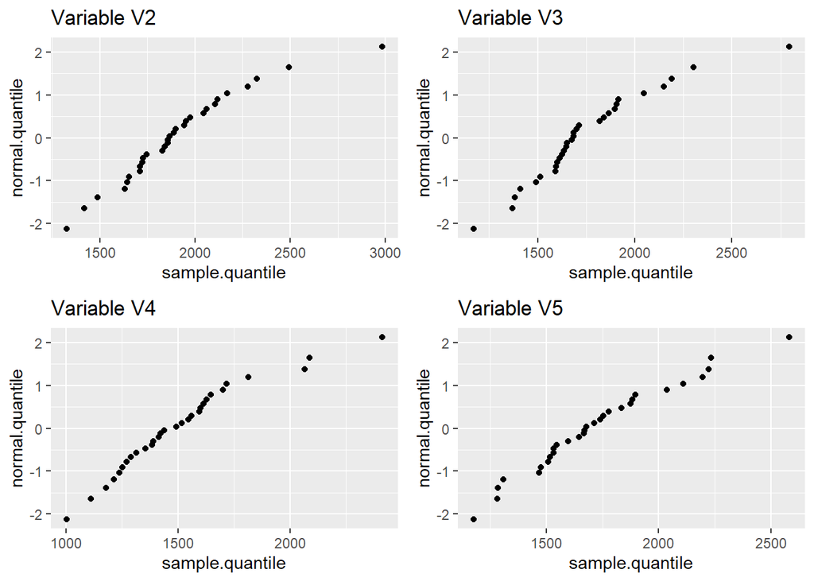

```r
## Normal Q-Q plot
X <- read.table("D:/Coursework/Stat 501 Spring 2020/Homework2/board.stiffness.dat", head = FALSE, row.names = 1)

QQplot.normal = function(x){
  # x is an observed vector of a variable
  x.sort = sort(x)
  n = length(x)
  p = ( c(1 : n) - 0.5 ) / n
  q = qnorm(p)
  res = data.frame(cbind(x.sort, q))
  names(res) = c("sample.quantile", "normal.quantile")
  return(res)
}


p1 <- ggplot(data = QQplot.normal(X$V2), aes(x = sample.quantile, y = normal.quantile)) + geom_point() +
  ggtitle("Variable V2")
p2 <- ggplot(data = QQplot.normal(X$V3), aes(x = sample.quantile, y = normal.quantile)) + geom_point() +
  ggtitle("Variable V3")
p3 <- ggplot(data = QQplot.normal(X$V4), aes(x = sample.quantile, y = normal.quantile)) + geom_point() +
  ggtitle("Variable V4")
p4 <- ggplot(data = QQplot.normal(X$V5), aes(x = sample.quantile, y = normal.quantile)) + geom_point() +
  ggtitle("Variable V5")
grid.arrange(p1, p2, p3, p4, nrow = 2, ncol = 2)
```

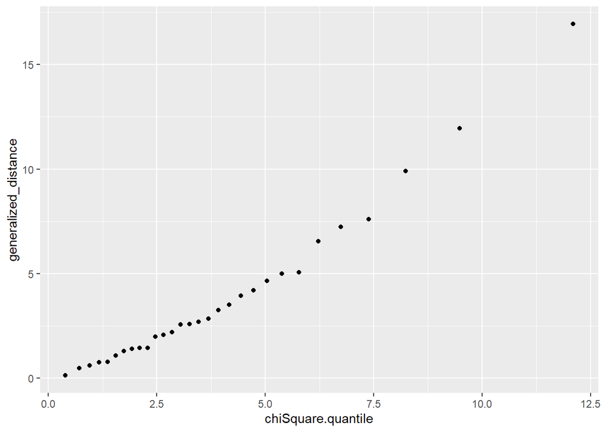

```r
## Chi square Q-Q plot
QQplot.chiSquare = function(data){
  # X is data set with p variables and n observations
  # Get p and n
  n <- dim(data)[1]
  p <- dim(data)[2]

  # Calculate mean and variance-covariance matrix
  mean <- apply(data, 2, "mean")
  cov <- cov(data)

  # Compute the generalized distances from the sample mean and covariance matrix
  diffs <- as.matrix(data - matrix(mean, nrow=n, ncol=p, byrow=TRUE))
  gdist <- diag(diffs %*% solve(cov) %*% t(diffs))

  # Sort the distances
  s.gdist <- sort(gdist)

  # Find the matching list of quantiles.
  prob <- (c(1:n) - 0.5)/n
  quant <- qchisq(prob, p)
  res = data.frame(cbind(s.gdist, quant))
  names(res) = c("generalized_distance", "chiSquare.quantile")

  return(res)
}

chi <- QQplot.chiSquare(X)
ggplot(data = chi, aes(x = chiSquare.quantile, y = generalized_distance)) + geom_point()
```

```r
testnormality <- function(X, numproj = 100000)  {
    p = ncol(X)
    n = nrow(X)
    x <- matrix(rnorm(numproj * p), nrow = p) # generate 100,000, standard
                                              # p-variate normal random variables.
    y <- matrix(sqrt(apply(x^2, 2, sum)), nrow = p, ncol = numproj, by = T)
    z <- x / y
    tempdat <- as.matrix(X) %*% z  # this gives rise to a p x numproj matrix
                                   # called tempdat here

    # perform Shapiro-Wilks' test and calculate individual p-values on each of
    # the numproj observation sets.
    pvals <- as.numeric(matrix(unlist(apply(tempdat, 2, shapiro.test)),
                             ncol=4, by = T)[,2])

    return(min(sort(pvals))) #return smallest pvalue
  }

testnormality(X)
```

```
## [1] 7.313303e-06
```

```r
n <- nrow(X)
cor.mat <- cor(X)
mean <- apply(X, 2, "mean")

#it wil take forever to do this step, sorry T_T
nboot <- 100
pvalue <- vector()
for (i in 1:nboot) {
  X.star <- mvrnorm(n, mean, cor.mat)
  p <- testnormality(X.star)
  pvalue <- c(pvalue, p)
}


#quantile to construct the reject region
quantile(pvalue, 0.025)
```

```
##        2.5%
## 0.000342558
```

```r
quantile(pvalue, 0.975)
```

```
##      97.5%
## 0.01820251
```

With this region, we reject the multivariate normality hypothesis on the stiffness data.